# STORYTELLING WITH OPEN DATA(GENDER PAY GAP)

2024-06-05

## DATAFRAME

|  | JobTitle | Gender | Age | PerfEval | Education | Dept | Seniority | BasePay | Bonus | Total_Salary |
| --- | --- | --- | --- | --- | --- | --- | --- | --- | --- | --- |
| 1 | Graphic Designer | Female | 18 | 5 | College | Operations | 2 | 42363 | 9938 | 52301 |
| 2 | Software Engineer | Male | 21 | 5 | College | Management | 5 | 108476 | 11128 | 119604 |
| 3 | Warehouse Associate | Female | 19 | 4 | PhD | Administration | 5 | 90208 | 9268 | 99476 |
| 4 | Software Engineer | Male | 20 | 5 | Masters | Sales | 4 | 108080 | 10154 | 118234 |
| 5 | Graphic Designer | Male | 26 | 5 | Masters | Engineering | 5 | 99464 | 9319 | 108783 |
| 6 | IT | Female | 20 | 5 | PhD | Operations | 4 | 70890 | 10126 | 81016 |
| 7 | Graphic Designer | Female | 20 | 5 | College | Sales | 4 | 67585 | 10541 | 78126 |
| 8 | Software Engineer | Male | 18 | 4 | PhD | Engineering | 5 | 97523 | 10240 | 107763 |
| 9 | Graphic Designer | Female | 33 | 5 | High School | Engineering | 5 | 112976 | 9836 | 122812 |
| 10 | Sales Associate | Female | 35 | 5 | College | Engineering | 5 | 106524 | 9941 | 116465 |

[output cut: 990 more lines]

## What is the Distribution of Educational qualifications in the data?

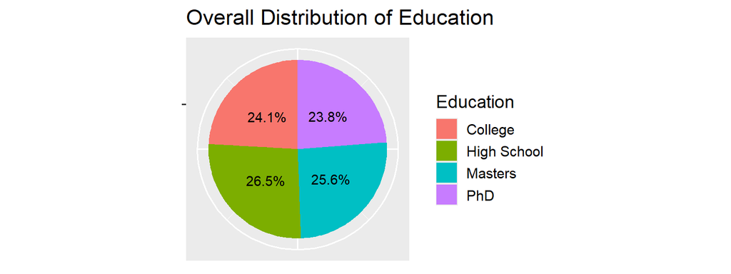

## Is there a connection between higher education and higher salaries?

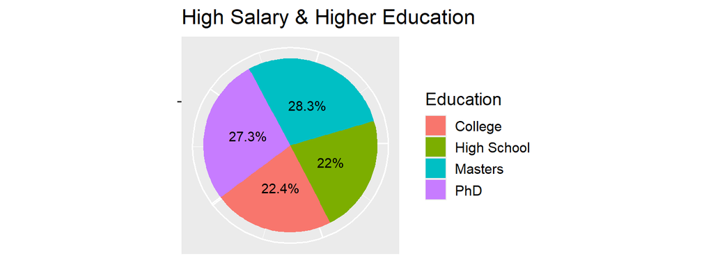

There is a notable connection between higher education (Master’s and PhD) and higher salaries. Individuals with these advanced degrees are more likely to be in the high salary group, while those with only a high school education are less likely to earn high salaries.

## How is High Salary related to Gender

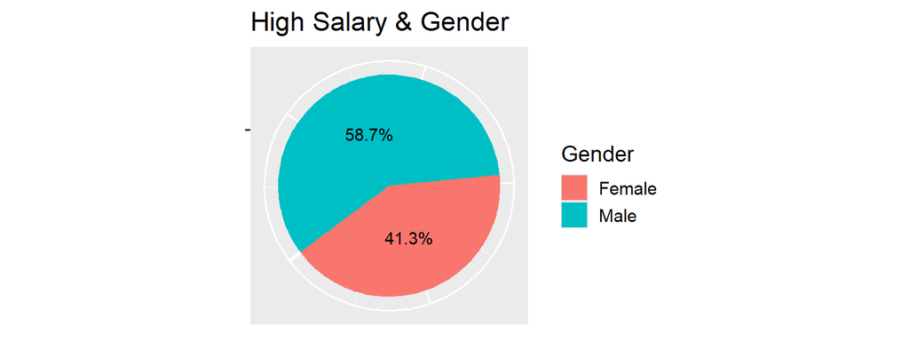

From the above pie chart we can clearly see that from the high salary group (which is people who earn six figures) males constitute 58.7% of the individuals earning high salaries. This indicates that a larger proportion of males are in the high salary bracket compared to females which are on 41.3%.

**Does gender influence salary differences, even when men and women have the same performance evaluation scores?**

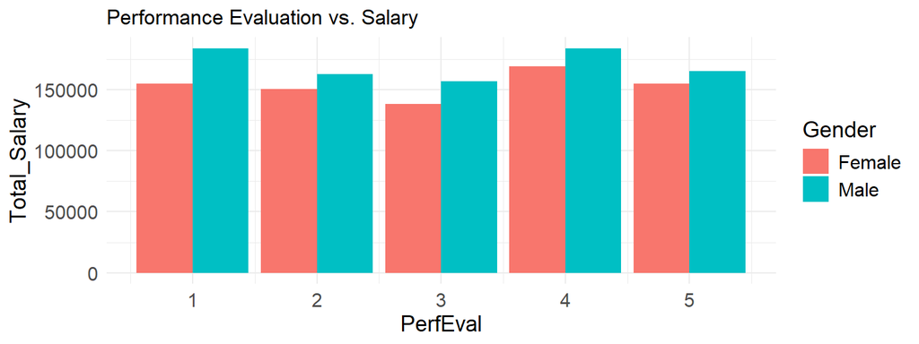

The chart indicates that, generally, males tend to have slightly higher salaries than females for the same performance evaluation scores,this suggests that gender may have an impact on the total salary

**Is there any significant difference between men and women regards to their salaries and seniority**

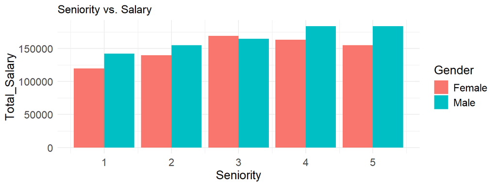

The chart indicates that males generally have higher salaries than females across different levels of seniority.This suggests that gender may have an impact on salary, with males often earning more than females even when they have the same level of seniority.

**Is there any significant difference between men and women regards to their salaries and education?**

[figure not shown]

The bar plot shows that men consistently earn more than women across all education levels. Specifically, for College, Masters, PhD, and High School education levels, men have higher total salaries compared to women, indicating a significant gender-based salary difference in favor of men

## Analysis of Gender-Based Salary Differences

**Men** earn **$26.49 more** in **bonus** than **women**  
**Women** earn **$4776.03 less** than **men** as **base pay**  
On average, **men** earn **$4802.52 more** than **women**

Men earn more than women in every component of the salary!!!But the question is WHY?